# homework from SA23204182

## hw8

### hw8_1.

$p(x_i \in (u_i,v_i)|\lambda)=e^{-\lambda u_i}-e^{-\lambda v_i}$, 故而似然函数为
$$f(\lambda
;\{(u_i,v_i)\}_{i=1}^n)=\prod_{i=1}^{n}(e^{-\lambda u_i}-e^{-\lambda
v_i}).$$

对数似然:
$$lnf(\lambda
;\{(u_i,v_i)\}_{i=1}^n)=\sum_{i=1}^{n}ln(e^{-\lambda u_i}-e^{-\lambda
v_i})$$

求解$\partial lnf(\lambda ;\{(u_i,v_i)\}_{i=1}^n)/\partial \lambda=0$, 得到解$\hat \lambda_{MLE}$. 其中
$$\frac{\partial lnf(\lambda
;\{(u_i,v_i)\}_{i=1}^n)}{\partial \lambda}=
\sum_{i=1}^{n}\frac{v_ie^{-\lambda v_i}-u_ie^{-\lambda u_i}}{e^{-\lambda
u_i}-e^{-\lambda v_i}}.$$

由于
$$\frac{\partial^2 lnf(\lambda
;\{(u_i,v_i)\}_{i=1}^n)}{\partial \lambda^2}=
\sum_{i=1}^{n}\frac{-(u_i-v_i)^2e^{-\lambda (u_i+v_i)}}{(e^{-\lambda
u_i}-e^{-\lambda v_i})^2}<0,$$

所以$\hat \lambda_{MLE}$即为直接极大化观测数据的似然函数得到的MLE估计。

EM算法：将$\{x_i\}_{i=1}^n$作为隐变量,则$f(\lambda ;\{(u_i,v_i)\},\{x_i\}_{i=1}^n)=\prod_{i=1}^n \lambda e^{-\lambda x_i}$, 进而
$$lnf(\lambda
;\{(u_i,v_i)\},\{x_i\}_{i=1}^n)=n \ ln\lambda -\lambda \sum_{i=1}^n
x_i.$$

**EM算法过程**:首先初始化$\lambda_0$.

在第t次迭代:

E-step: 计算
$$E_{\lambda_{t-1}}[ln
f(\lambda
;\{(u_i,v_i)\},\{x_i\}_{i=1}^n)|\{(u_i,v_i)\}_{i=1}^n]=nln\lambda-\lambda
\sum_{i}E_{\lambda_{t-1}}[x_i|(u_i,v_i)],$$
其中
$$E_{\lambda_{t-1}}[x|(u,v)]=\frac{(\lambda_{t-1}
u+1)e^{\lambda_{t-1} v}-(\lambda_{t-1} v+1)e^{\lambda_{t-1}
u}}{\lambda_{t-1}(e^{\lambda_{t-1} v}-e^{\lambda_{t-1}
u})}.$$

M-step: 求解
$$\lambda
_{t}=argmax_\lambda\ E_{\lambda_{t-1}}[ln f(\lambda
;\{(u_i,v_i)\},\{x_i\}_{i=1}^n)|\{(u_i,v_i)\}_{i=1}^n],$$
即
$$\lambda
_{t}=n/\sum_{i}E_{\lambda_{t-1}}[x_i|(u_i,v_i)].$$

**收敛性证明:**

由于
$$f(\{(u_i,v_i)\}_{i=1}^n|\lambda)=\frac{f(\{x_i\}_{i=1}^n,\{(u_i,v_i)\}_{i=1}^n|\lambda
)}{f(\{x_i\}_{i=1}^n|\lambda ,\{(u_i,v_i)\})},$$

所以
$$lnf(\{(u_i,v_i)\}_{i=1}^n|\lambda)=lnf(\{x_i\}_{i=1}^n,\{(u_i,v_i)\}_{i=1}^n|\lambda
)-ln f(\{x_i\}_{i=1}^n|\lambda ,\{(u_i,v_i)\}),$$
两边对$x|\lambda_{t-1} ,(u,v)$求期望,可以得到:

$$(*)\quad
lnf(\{(u_i,v_i)\}_{i=1}^n|\lambda)=E_{\lambda_{t-1}}lnf(\{x_i\}_{i=1}^n,\{(u_i,v_i)\}_{i=1}^n|\lambda
)-E_{\lambda_{t-1}}ln f(\{x_i\}_{i=1}^n|\lambda
,\{(u_i,v_i)\}),$$

EM算法中M步即为最大化(*)式中的第一项,进而有
$$(1)\quad
E_{\lambda_{t-1}}lnf(\{x_i\}_{i=1}^n,\{(u_i,v_i)\}_{i=1}^n|\lambda_{t}
)-E_{\lambda_{t-1}}lnf(\{x_i\}_{i=1}^n,\{(u_i,v_i)\}_{i=1}^n|\lambda_{t-1}
) \ge 0.$$

对于(*)第二项, 由于
$$(2)\quad
-E_{\lambda_{t-1}}ln f(\{x_i\}_{i=1}^n|\lambda_t
,\{(u_i,v_i)\})+E_{\lambda_{t-1}}ln f(\{x_i\}_{i=1}^n|\lambda_{t-1}
,\{(u_i,v_i)\})=\\
\qquad KL(f(\{x_i\}_{i=1}^n|\lambda_{t-1}
,\{(u_i,v_i)\})||f(\{x_i\}_{i=1}^n|\lambda_t,\{(u_i,v_i)\}))\ge
0.$$

这里利用了KL距离正定的性质.

结合(1)(2),可以得到
$$lnf(\{(u_i,v_i)\}_{i=1}^n|\lambda_{t-1})\le
lnf(\{(u_i,v_i)\}_{i=1}^n|\lambda_{t}), \forall t.$$

即似然函数$lnf(\{(u_i,v_i)\}_{i=1}^n|\lambda_{t})$为t的非减函数, 进而其关于t收敛。又由于(1)(2)恒非负, 所以这两项各自收敛到0. 结合(2)收敛到零以及KL距离性质易知$\lambda_t$收敛.

又由于

$$\frac 1 {\lambda_{t}}- \frac 1
{\lambda_{t-1}}
=\frac{1}n \sum_i \frac{u_ie^{\lambda_{t-1} v_i}-v_ie^{\lambda_{t-1}
u_i}}{e^{\lambda_{t-1} v_i}-e^{-\lambda_{t-1} u_i}}
=-\frac{\partial lnf(\lambda ;\{(u_i,v_i)\}_{i=1}^n)/n}{\partial
\lambda}|_{\lambda=\lambda_{t-1}}.$$
即序列$\{\lambda_{t}\}_{t=0}^\infty$的收敛点$\hat\lambda_{EM}$满足
$$\frac{\partial lnf(\lambda
;\{(u_i,v_i)\}_{i=1}^n)}{\partial
\lambda}|_{\lambda=\hat\lambda_{EM}}=0,$$

即
$$\hat \lambda_{EM}=\hat \lambda_{MLE} \
.$$

**以上的内容证明了EM算法确实会收敛到MLE解**

**下面我们来证明收敛是线性的**

下面这部分证明了$(\lambda_t-\lambda_{t-1})/(\lambda_{t-1}-\lambda_{t-2})$ 收敛到一个固定值.

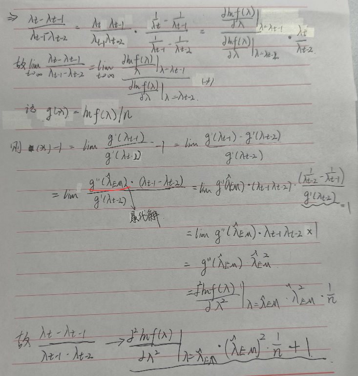

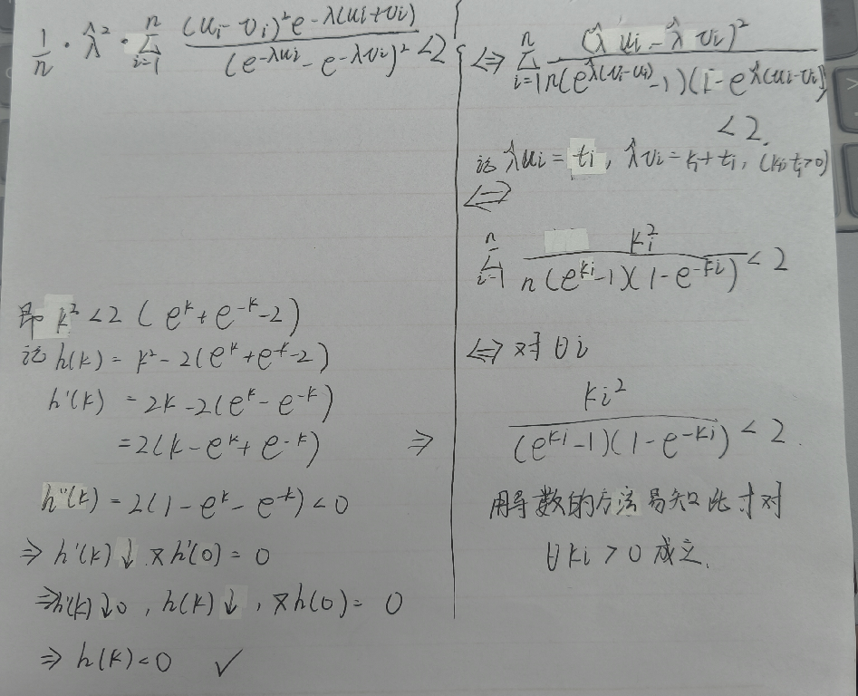

也可以用不动点引理

Banach不动点定理是数学中的一个重要定理，它在函数空间和完备度量空间中的收缩映射上有广泛应用。定理的正式表述如下：

**Banach不动点定理：** 设 $(X, d)$ 是一个完备度量空间，$T: X \rightarrow X$ 是一个将 $X$ 映射到自身的收缩映射，即存在一个常数 $0 \leq k < 1$，对于所有 $x, y \in X$ 有 $d(Tx, Ty) \leq k \cdot d(x, y)$。那么，存在唯一的 $x^* \in X$ 使得 $Tx^* = x^*$，即 $x^*$ 是 $T$ 的不动点。

这个定理的证明主要基于完备度量空间的柯西序列理论和收缩映射的性质。关键的思想是通过逐步迭代映射 $T$ 的序列，证明该序列在度量空间中收敛，并极限点即为不动点。唯一性的证明则利用了收缩映射的性质。

Banach不动点定理在许多数学和应用领域中都有重要应用，特别是在解微分方程、积分方程和优化问题时。它为这些问题的存在性和唯一性提供了一个强有力的工具。

```r
#区间
u<-c(11,8,27,13,16,0,23,10,24,2)
v<-c(12,9,28,14,17,1,24,11,25,3)
#对数似然的导数
gl<-function(lambda){
  sum((v*exp(-lambda*v)-u*exp(-lambda*u))/(exp(-lambda*u)-exp(-lambda*v)))
}
#直接求解MLE
lam_mle<-uniroot(gl,c(0,1),extendInt = "yes")$root

#EM算法:
lam0<-0.05#初始化
N<-1e3
tol<-1e-6
for(iter in 1:N){
  lam1<-1/(1/lam0-1/length(u)*gl(lam0))
  if((abs(lam1-lam0)/lam0)<=tol) break
  lam0<-lam1
}
lam_EM<-lam1

#结果
c("MLE"=lam_mle,"EM"=lam_EM)
```

```
##        MLE         EM
## 0.07196174 0.07197350
```